# Assignment2

Tharindu Madusanka Uyanahewa s4668998

1/3/2022

```r
library(data.table)
library(plotly)
library(randomForest)
library(yaml)
library(tidyverse)
library(knitr)
library(dplyr)
library(skimr)
library(tibble)
library(rmarkdown)
library(tidyr)
library(ggplot2)
library(ggforce)

library(widyr)
```

```r
thanksgiving_meals <- read_csv("https://raw.githubusercontent.com/rfordatascience/tidytuesday/master/data/2018/2018-11-20/thanksgiving_meals.csv")
```

#1. Create an Rmarkdown document with webpage as output (same as in setup)

#At the start of the output document include your name in italic font and #your student id in bold font as level 2 heading

*Tharindu Uyanahewa*

## **s4668998**

#——————————————————————————————————–

### Part 2: Data Wrangling and visualization

#1. Display the first 10 rows of the dataset using `kable()` function

```r
head(thanksgiving_meals,10) %>%
  kable()
```

| id | celebrate | main_dish | main_dish_other | main_prep | main_prep_other | stuffing | stuffing_other | cranberry | cranberry_other | gravy | side1 | side2 | side3 | side4 | side5 | side6 | side7 | side8 | side9 | side10 | side11 | side12 | side13 | side14 | side15 | pie1 | pie2 | pie3 | pie4 | … |
| --- | --- | --- | --- | --- | --- | --- | --- | --- | --- | --- | --- | --- | --- | --- | --- | --- | --- | --- | --- | --- | --- | --- | --- | --- | --- | --- | --- | --- | --- | --- |
| 4337954960 | Yes | Turkey | NA | Baked | NA | Bread-based | NA | None | NA | Yes | NA | Carrots | NA | NA | NA | NA | Green beans/green bean casserole | Macaroni and cheese | Mashed potatoes | NA | NA | NA | Yams/sweet potato casserole | NA | NA | Apple | NA | NA | NA | … |
| 4337951949 | Yes | Turkey | NA | Baked | NA | Bread-based | NA | Other (please specify) | Homemade cranberry gelatin ring | Yes | NA | NA | NA | Corn | NA | NA | Green beans/green bean casserole | Macaroni and cheese | Mashed potatoes | Rolls/biscuits | NA | Vegetable salad | Yams/sweet potato casserole | Other (please specify) | Asian vinagrette salad | Apple | NA | NA | Chocolate | … |
| 4337935621 | Yes | Turkey | NA | Roasted | NA | Rice-based | NA | Homemade | NA | Yes | Brussel sprouts | Carrots | Cauliflower | Corn | Cornbread | NA | NA | NA | Mashed potatoes | Rolls/biscuits | NA | Vegetable salad | NA | NA | NA | Apple | NA | Cherry | NA | … |
| 4337933040 | Yes | Turkey | NA | Baked | NA | Bread-based | NA | Homemade | NA | Yes | Brussel sprouts | NA | NA | NA | Cornbread | NA | NA | NA | Mashed potatoes | Rolls/biscuits | NA | Vegetable salad | Yams/sweet potato casserole | NA | NA | NA | NA | NA | NA | … |
| 4337931983 | Yes | Tofurkey | NA | Baked | NA | Bread-based | NA | Canned | NA | Yes | Brussel sprouts | NA | NA | NA | Cornbread | NA | NA | NA | Mashed potatoes | Rolls/biscuits | Squash | Vegetable salad | Yams/sweet potato casserole | NA | NA | Apple | NA | NA | NA | … |
| 4337929779 | Yes | Turkey | NA | Roasted | NA | Rice-based | NA | Homemade | NA | Yes | Brussel sprouts | Carrots | Cauliflower | Corn | Cornbread | Fruit salad | Green beans/green bean casserole | Macaroni and cheese | Mashed potatoes | Rolls/biscuits | Squash | Vegetable salad | Yams/sweet potato casserole | NA | NA | NA | NA | NA | NA | … |
| 4337924420 | Yes | Turkey | NA | Baked | NA | Bread-based | NA | Canned | NA | Yes | NA | NA | NA | NA | NA | Fruit salad | Green beans/green bean casserole | NA | Mashed potatoes | Rolls/biscuits | NA | NA | Yams/sweet potato casserole | NA | NA | Apple | NA | NA | NA | … |
| 4337916002 | Yes | Turkey | NA | Baked | NA | Rice-based | NA | Homemade | NA | Yes | NA | Carrots | NA | NA | NA | NA | NA | NA | NA | NA | NA | NA | NA | NA | NA | NA | NA | NA | Chocolate | … |
| 4337914977 | Yes | Turkey | NA | Roasted | NA | Bread-based | NA | Canned | NA | Yes | Brussel sprouts | NA | NA | Corn | Cornbread | NA | Green beans/green bean casserole | NA | Mashed potatoes | Rolls/biscuits | Squash | NA | NA | NA | NA | Apple | Buttermilk | NA | NA | … |
| 4337899817 | Yes | Other (please specify) | Turkey and Ham | Baked | NA | Bread-based | NA | Other (please specify) | Both Canned and Homemade | Yes | Brussel sprouts | Carrots | NA | NA | NA | NA | Green beans/green bean casserole | NA | Mashed potatoes | Rolls/biscuits | NA | NA | Yams/sweet potato casserole | NA | NA | NA | Buttermilk | NA | NA | … |

#2. Using `skim()` display the summary of variables.

```r
skim(thanksgiving_meals)
```

Data summary

| Name | thanksgiving_meals |
| --- | --- |
| Number of rows | 1058 |
| Number of columns | 65 |
| _______________________ |  |
| Column type frequency: |  |
| character | 64 |
| numeric | 1 |
| ________________________ |  |
| Group variables | None |

**Variable type: character**

| skim_variable | n_missing | complete_rate | min | max | empty | n_unique | whitespace |
| --- | --- | --- | --- | --- | --- | --- | --- |
| celebrate | 0 | 1.00 | 2 | 3 | 0 | 2 | 0 |
| main_dish | 84 | 0.92 | 6 | 22 | 0 | 8 | 0 |
| main_dish_other | 1023 | 0.03 | 4 | 85 | 0 | 32 | 0 |
| main_prep | 84 | 0.92 | 5 | 22 | 0 | 5 | 0 |
| main_prep_other | 1007 | 0.05 | 1 | 33 | 0 | 32 | 0 |
| stuffing | 84 | 0.92 | 4 | 22 | 0 | 4 | 0 |
| stuffing_other | 1022 | 0.03 | 4 | 46 | 0 | 29 | 0 |
| cranberry | 84 | 0.92 | 4 | 22 | 0 | 4 | 0 |
| cranberry_other | 1033 | 0.02 | 3 | 61 | 0 | 24 | 0 |
| gravy | 84 | 0.92 | 2 | 3 | 0 | 2 | 0 |
| side1 | 903 | 0.15 | 15 | 15 | 0 | 1 | 0 |
| side2 | 816 | 0.23 | 7 | 7 | 0 | 1 | 0 |
| side3 | 970 | 0.08 | 11 | 11 | 0 | 1 | 0 |
| side4 | 594 | 0.44 | 4 | 4 | 0 | 1 | 0 |
| side5 | 823 | 0.22 | 9 | 9 | 0 | 1 | 0 |
| side6 | 843 | 0.20 | 11 | 11 | 0 | 1 | 0 |
| side7 | 372 | 0.65 | 32 | 32 | 0 | 1 | 0 |
| side8 | 852 | 0.19 | 19 | 19 | 0 | 1 | 0 |
| side9 | 241 | 0.77 | 15 | 15 | 0 | 1 | 0 |
| side10 | 292 | 0.72 | 14 | 14 | 0 | 1 | 0 |
| side11 | 887 | 0.16 | 6 | 6 | 0 | 1 | 0 |
| side12 | 849 | 0.20 | 15 | 15 | 0 | 1 | 0 |
| side13 | 427 | 0.60 | 27 | 27 | 0 | 1 | 0 |
| side14 | 947 | 0.10 | 22 | 22 | 0 | 1 | 0 |
| side15 | 947 | 0.10 | 4 | 78 | 0 | 89 | 0 |
| pie1 | 544 | 0.49 | 5 | 5 | 0 | 1 | 0 |
| pie2 | 1023 | 0.03 | 10 | 10 | 0 | 1 | 0 |
| pie3 | 945 | 0.11 | 6 | 6 | 0 | 1 | 0 |
| pie4 | 925 | 0.13 | 9 | 9 | 0 | 1 | 0 |
| pie5 | 1022 | 0.03 | 13 | 13 | 0 | 1 | 0 |
| pie6 | 1019 | 0.04 | 8 | 8 | 0 | 1 | 0 |
| pie7 | 1024 | 0.03 | 5 | 5 | 0 | 1 | 0 |
| pie8 | 716 | 0.32 | 5 | 5 | 0 | 1 | 0 |
| pie9 | 329 | 0.69 | 7 | 7 | 0 | 1 | 0 |
| pie10 | 906 | 0.14 | 12 | 12 | 0 | 1 | 0 |
| pie11 | 1018 | 0.04 | 4 | 4 | 0 | 1 | 0 |
| pie12 | 987 | 0.07 | 22 | 22 | 0 | 1 | 0 |
| pie13 | 987 | 0.07 | 5 | 46 | 0 | 61 | 0 |
| dessert1 | 948 | 0.10 | 13 | 13 | 0 | 1 | 0 |
| dessert2 | 1042 | 0.02 | 8 | 8 | 0 | 1 | 0 |
| dessert3 | 930 | 0.12 | 8 | 8 | 0 | 1 | 0 |
| dessert4 | 986 | 0.07 | 11 | 11 | 0 | 1 | 0 |
| dessert5 | 867 | 0.18 | 10 | 10 | 0 | 1 | 0 |
| dessert6 | 854 | 0.19 | 7 | 7 | 0 | 1 | 0 |
| dessert7 | 1015 | 0.04 | 5 | 5 | 0 | 1 | 0 |
| dessert8 | 792 | 0.25 | 9 | 9 | 0 | 1 | 0 |
| dessert9 | 955 | 0.10 | 13 | 13 | 0 | 1 | 0 |
| dessert10 | 763 | 0.28 | 4 | 4 | 0 | 1 | 0 |
| dessert11 | 924 | 0.13 | 22 | 22 | 0 | 1 | 0 |
| dessert12 | 924 | 0.13 | 3 | 59 | 0 | 92 | 0 |
| prayer | 99 | 0.91 | 2 | 3 | 0 | 2 | 0 |
| travel | 107 | 0.90 | 59 | 80 | 0 | 4 | 0 |
| watch_program | 556 | 0.47 | 13 | 13 | 0 | 1 | 0 |
| kids_table_age | 107 | 0.90 | 2 | 13 | 0 | 12 | 0 |
| hometown_friends | 107 | 0.90 | 2 | 3 | 0 | 2 | 0 |
| friendsgiving | 107 | 0.90 | 2 | 3 | 0 | 2 | 0 |
| black_friday | 107 | 0.90 | 2 | 3 | 0 | 2 | 0 |
| work_retail | 107 | 0.90 | 2 | 3 | 0 | 2 | 0 |
| work_black_friday | 988 | 0.07 | 2 | 13 | 0 | 3 | 0 |
| community_type | 110 | 0.90 | 5 | 8 | 0 | 3 | 0 |
| age | 33 | 0.97 | 3 | 7 | 0 | 4 | 0 |
| gender | 33 | 0.97 | 4 | 6 | 0 | 2 | 0 |
| family_income | 33 | 0.97 | 12 | 20 | 0 | 11 | 0 |
| us_region | 59 | 0.94 | 7 | 18 | 0 | 9 | 0 |

**Variable type: numeric**

| skim_variable | n_missing | complete_rate | mean | sd | p0 | p25 | p50 | p75 | p100 | hist |
| --- | --- | --- | --- | --- | --- | --- | --- | --- | --- | --- |
| id | 0 | 1 | 4336731188 | 493783.4 | 4335894916 | 4336339486 | 4336796628 | 4337012140 | 4337954960 | ▅▃▇▂▂ |

#Think about the task to predict a family income based on their menu: what variables may be useful? Are all of them correct type? #Write 2-3 sentences with your explanation.

#There are few variables can be considered. Variables such as, “main_dish” and “stuffing” can be considered as input variables while “family_income” variable is taken as output variable for prediction. #It is noticed that all variables are string/character type (except “id” variable) and need to convet them as factor variables.

#Think about the task to predict a community type or US_region based on their menu: what variables may be useful? Are all of them correct type?

#“slide10” and “pie9” variables are taken as input variable due to majority of them consumed while “us_region” is considered as output variable. All of the variables are in String/character type and need to convet them as factor variables due to that reason classification method should be used for predication.

#3. Use `fct_reorder` and `parse_number` functions to create a factor variable `family_income`

```r
thanksgiving_meals %>%
mutate(family_income = fct_reorder(family_income, parse_number(family_income)))
```

```
## # A tibble: 1,058 x 65
##        id celebrate main_dish main_dish_other main_prep main_prep_other stuffing
##     <dbl> <chr>     <chr>     <chr>           <chr>     <chr>           <chr>
##  1 4.34e9 Yes       Turkey    <NA>            Baked     <NA>            Bread-b~
##  2 4.34e9 Yes       Turkey    <NA>            Baked     <NA>            Bread-b~
##  3 4.34e9 Yes       Turkey    <NA>            Roasted   <NA>            Rice-ba~
##  4 4.34e9 Yes       Turkey    <NA>            Baked     <NA>            Bread-b~
##  5 4.34e9 Yes       Tofurkey  <NA>            Baked     <NA>            Bread-b~
##  6 4.34e9 Yes       Turkey    <NA>            Roasted   <NA>            Rice-ba~
##  7 4.34e9 Yes       Turkey    <NA>            Baked     <NA>            Bread-b~
##  8 4.34e9 Yes       Turkey    <NA>            Baked     <NA>            Rice-ba~
##  9 4.34e9 Yes       Turkey    <NA>            Roasted   <NA>            Bread-b~
## 10 4.34e9 Yes       Other (p~ Turkey and Ham  Baked     <NA>            Bread-b~
## # ... with 1,048 more rows, and 58 more variables: stuffing_other <chr>,
## #   cranberry <chr>, cranberry_other <chr>, gravy <chr>, side1 <chr>,
## #   side2 <chr>, side3 <chr>, side4 <chr>, side5 <chr>, side6 <chr>,
## #   side7 <chr>, side8 <chr>, side9 <chr>, side10 <chr>, side11 <chr>,
## #   side12 <chr>, side13 <chr>, side14 <chr>, side15 <chr>, pie1 <chr>,
## #   pie2 <chr>, pie3 <chr>, pie4 <chr>, pie5 <chr>, pie6 <chr>, pie7 <chr>,
## #   pie8 <chr>, pie9 <chr>, pie10 <chr>, pie11 <chr>, pie12 <chr>, ...
```

#4. What is the number of people who celebrate?

```r
thanksgiving_meals %>%
count(celebrate == "Yes") %>%
kable()
```

| celebrate == “Yes” | n |
| --- | --- |
| FALSE | 78 |
| TRUE | 980 |

```r
#Should be considered true values
```

#5. What are categories and insights for each main dish served and the method it is prepared?

```r
#filter(unique_thanksgiving_meals, main_dish,main_prep)

distinct(thanksgiving_meals, main_dish,main_prep,.keep_all = FALSE)
```

```
## # A tibble: 31 x 2
##    main_dish              main_prep
##    <chr>                  <chr>
##  1 Turkey                 Baked
##  2 Turkey                 Roasted
##  3 Tofurkey               Baked
##  4 Other (please specify) Baked
##  5 <NA>                   <NA>
##  6 Ham/Pork               Roasted
##  7 Turducken              Roasted
##  8 Turkey                 Fried
##  9 Other (please specify) Other (please specify)
## 10 Turkey                 I don't know
## # ... with 21 more rows
```

#6. Create 3 different data viz showing insights for main dish served and the method. Provide your own legend and use themes. #Write 2-3 sentences with your explanation of each insight.

#Below bar char displays total consumption of main dish. ggplot and coord_flip () functions are used for bar chart

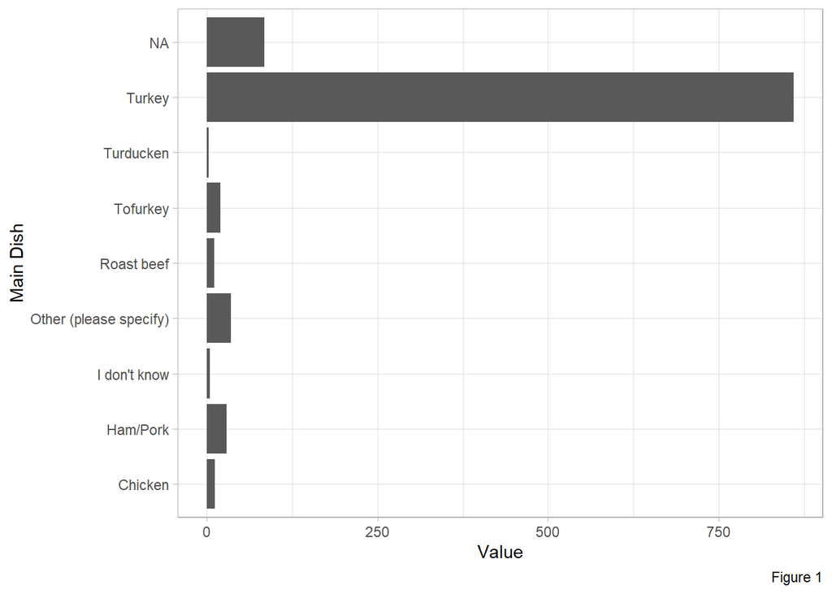

```r
thanksgiving_meals %>%

  ggplot(aes(x = main_dish)) +
geom_bar() +
  coord_flip() +

  labs(y= "Value", x = "Main Dish",colour = "main_dish",
     tiltle = " Distribution of Main Dish", caption = "Figure 1") +
  theme_light()
```

#Below graph shows plot distribution in between Family Income and Main Dish and gglot function is used.

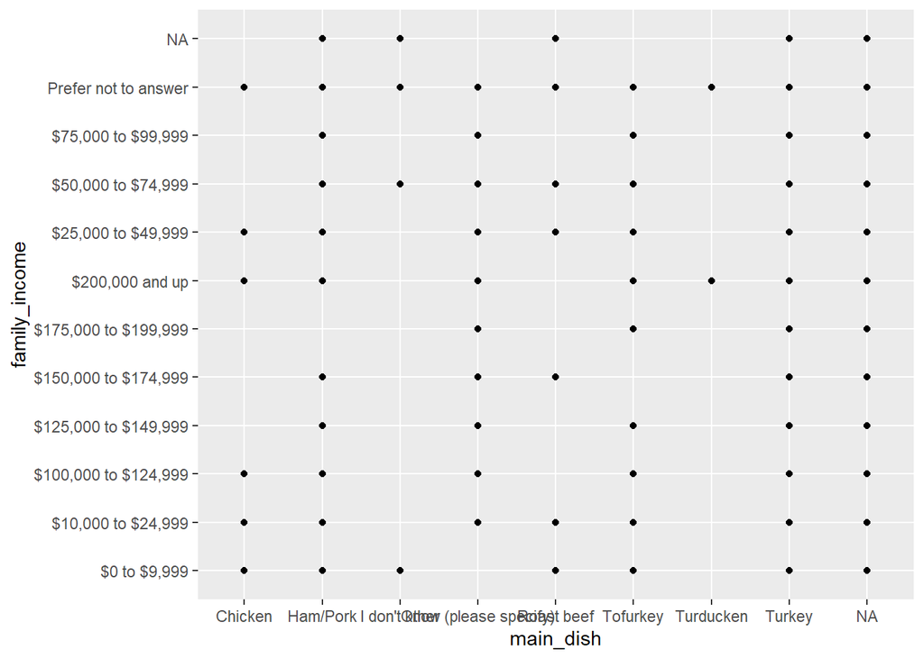

```r
ggplot(data = thanksgiving_meals, aes(x = main_dish, y = family_income)) +
  geom_point()
```

#Below graph displays data distribution of main_dish by using facet_wrap function

```r
  thanksgiving_meals %>%
  select(c(family_income,main_dish))
```

```
## # A tibble: 1,058 x 2
##    family_income        main_dish
##    <chr>                <chr>
##  1 $75,000 to $99,999   Turkey
##  2 $50,000 to $74,999   Turkey
##  3 $0 to $9,999         Turkey
##  4 $200,000 and up      Turkey
##  5 $100,000 to $124,999 Tofurkey
##  6 $0 to $9,999         Turkey
##  7 $25,000 to $49,999   Turkey
##  8 Prefer not to answer Turkey
##  9 $75,000 to $99,999   Turkey
## 10 $25,000 to $49,999   Other (please specify)
## # ... with 1,048 more rows
```

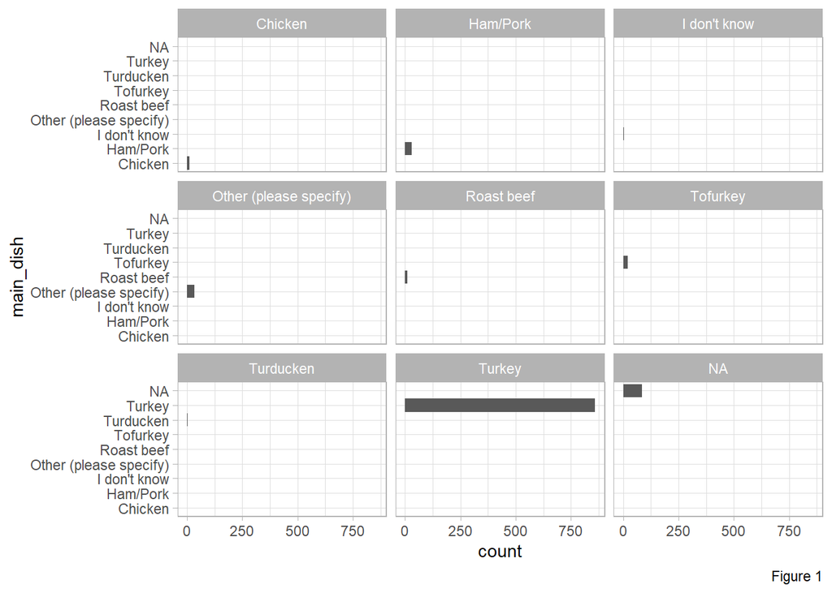

```r
ggplot(data = thanksgiving_meals, aes(x = main_dish)) +
geom_bar() +
  coord_flip() +
facet_wrap(~thanksgiving_meals$main_dish) +
  labs(y= "count", y = "main_dish",colour = "main_dish",
     tiltle = " Distribution of main_dish", caption = "Figure 1") +
  theme_light()
```

#7. How many use cranberry sauce? How many use gravy?

```r
thanksgiving_meals %>%
count(cranberry == "Homemade" | cranberry == "Canned" | cranberry == "Other (please specify)") %>%
kable()
```

| \|… | n |
| --- | --- |
| FALSE | 146 |
| TRUE | 828 |
| NA | 84 |

```r
thanksgiving_meals %>%
count(gravy == "Yes") %>%
  kable()
```

| gravy == “Yes” | n |
| --- | --- |
| FALSE | 82 |
| TRUE | 892 |
| NA | 84 |

#8-9. What is the distribution of those who celebrate across income ranges. Create a data viz. #Write 2-3 sentences with your explanation of each insight.

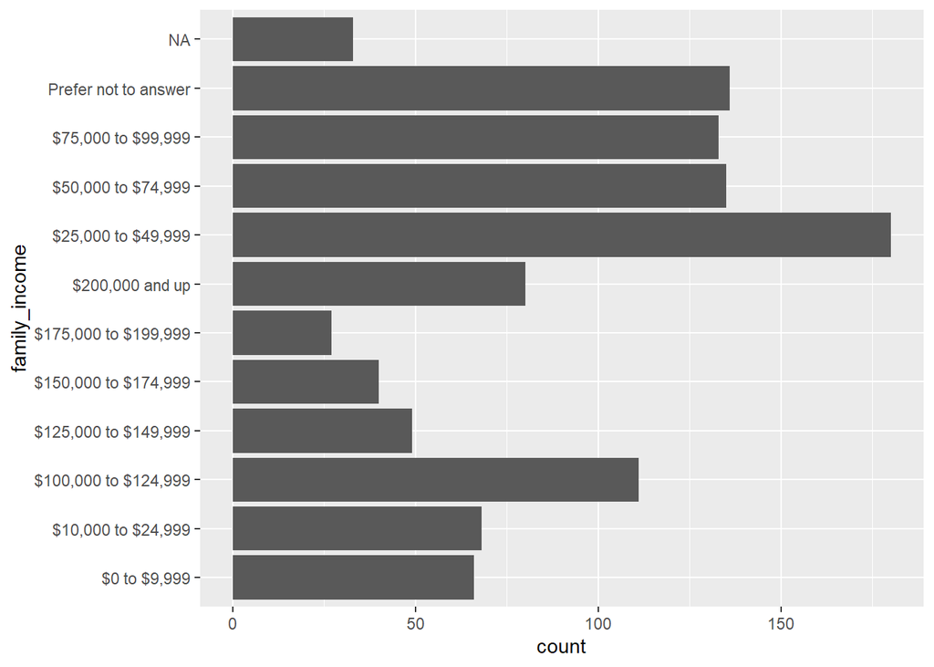

```r
ggplot(thanksgiving_meals, aes(y=family_income)) +
  geom_bar(celebrate = "Yes")
```

#10. Use the following code to create a new data set

```r
new_dataset  <- thanksgiving_meals %>%

select(id, starts_with("side"),
         starts_with("pie"),
         starts_with("dessert")) %>%
  select(-side15, -pie13, -dessert12) %>%
  gather(type, value, -id) %>%
  filter(!is.na(value),
         !value %in% c("None", "Other (please specify)")) %>%
  mutate(type = str_remove(type, "\\d+"))
```

#Write 2-3 sentences with your explanation of what it does.

#11-12. Intall package `widyr` and use `pairwise_cor()` function https://www.rdocumentation.org/packages/widyr/versions/0.1.3/topics/pairwise_cor #Write 2-3 sentences with your explanation of what it does.

#“pairwise_cor” function searches correlations of items pairs in a column, according to a “feature” column that connects them together. It cmes under “widyr” package. According to the data set it shows the how corerelate item1 and item2 with corerelation value.

#Use this code for the new dataset #pairwise_cor(value, id, sort = TRUE)

```r
new_dataset  %>%
pairwise_cor(value, id, sort = TRUE)
```

```
## # A tibble: 992 x 3
##    item1               item2               correlation
##    <chr>               <chr>                     <dbl>
##  1 Cookies             Brownies                  0.411
##  2 Brownies            Cookies                   0.411
##  3 Sweet Potato        Macaroni and cheese       0.365
##  4 Macaroni and cheese Sweet Potato              0.365
##  5 Rolls/biscuits      Mashed potatoes           0.341
##  6 Mashed potatoes     Rolls/biscuits            0.341
##  7 Peach cobbler       Sweet Potato              0.339
##  8 Sweet Potato        Peach cobbler             0.339
##  9 Pumpkin             Mashed potatoes           0.290
## 10 Mashed potatoes     Pumpkin                   0.290
## # ... with 982 more rows
```

#13. Use `lm()` or randomForest() function to build a model that predict a family income based on data in the dataset.

#Compare 3 models using different set of input variables. Use different number of variables.

```r
thanksgiving_mealsV2 <- thanksgiving_meals

thanksgiving_mealsV2
```

```
## # A tibble: 1,058 x 65
##        id celebrate main_dish main_dish_other main_prep main_prep_other stuffing
##     <dbl> <chr>     <chr>     <chr>           <chr>     <chr>           <chr>
##  1 4.34e9 Yes       Turkey    <NA>            Baked     <NA>            Bread-b~
##  2 4.34e9 Yes       Turkey    <NA>            Baked     <NA>            Bread-b~
##  3 4.34e9 Yes       Turkey    <NA>            Roasted   <NA>            Rice-ba~
##  4 4.34e9 Yes       Turkey    <NA>            Baked     <NA>            Bread-b~
##  5 4.34e9 Yes       Tofurkey  <NA>            Baked     <NA>            Bread-b~
##  6 4.34e9 Yes       Turkey    <NA>            Roasted   <NA>            Rice-ba~
##  7 4.34e9 Yes       Turkey    <NA>            Baked     <NA>            Bread-b~
##  8 4.34e9 Yes       Turkey    <NA>            Baked     <NA>            Rice-ba~
##  9 4.34e9 Yes       Turkey    <NA>            Roasted   <NA>            Bread-b~
## 10 4.34e9 Yes       Other (p~ Turkey and Ham  Baked     <NA>            Bread-b~
## # ... with 1,048 more rows, and 58 more variables: stuffing_other <chr>,
## #   cranberry <chr>, cranberry_other <chr>, gravy <chr>, side1 <chr>,
## #   side2 <chr>, side3 <chr>, side4 <chr>, side5 <chr>, side6 <chr>,
## #   side7 <chr>, side8 <chr>, side9 <chr>, side10 <chr>, side11 <chr>,
## #   side12 <chr>, side13 <chr>, side14 <chr>, side15 <chr>, pie1 <chr>,
## #   pie2 <chr>, pie3 <chr>, pie4 <chr>, pie5 <chr>, pie6 <chr>, pie7 <chr>,
## #   pie8 <chr>, pie9 <chr>, pie10 <chr>, pie11 <chr>, pie12 <chr>, ...
```

```r
thanksgiving_mealsV2$family_income = as.factor(thanksgiving_mealsV2$family_income)

factor(thanksgiving_mealsV2$family_income)
```

[output not shown]

[output cut: 339 more lines]

```r
str(thanksgiving_mealsV2)
```

```
## spec_tbl_df [1,058 x 65] (S3: spec_tbl_df/tbl_df/tbl/data.frame)
##  $ id               : num [1:1058] 4.34e+09 4.34e+09 4.34e+09 4.34e+09 4.34e+09 ...
##  $ celebrate        : chr [1:1058] "Yes" "Yes" "Yes" "Yes" ...
##  $ main_dish        : chr [1:1058] "Turkey" "Turkey" "Turkey" "Turkey" ...
##  $ main_dish_other  : chr [1:1058] NA NA NA NA ...
##  $ main_prep        : chr [1:1058] "Baked" "Baked" "Roasted" "Baked" ...
##  $ main_prep_other  : chr [1:1058] NA NA NA NA ...
##  $ stuffing         : chr [1:1058] "Bread-based" "Bread-based" "Rice-based" "Bread-based" ...
##  $ stuffing_other   : chr [1:1058] NA NA NA NA ...
##  $ cranberry        : chr [1:1058] "None" "Other (please specify)" "Homemade" "Homemade" ...
##  $ cranberry_other  : chr [1:1058] NA "Homemade cranberry gelatin ring" NA NA ...
##  $ gravy            : chr [1:1058] "Yes" "Yes" "Yes" "Yes" ...
##  $ side1            : chr [1:1058] NA NA "Brussel sprouts" "Brussel sprouts" ...
##  $ side2            : chr [1:1058] "Carrots" NA "Carrots" NA ...
##  $ side3            : chr [1:1058] NA NA "Cauliflower" NA ...
##  $ side4            : chr [1:1058] NA "Corn" "Corn" NA ...
##  $ side5            : chr [1:1058] NA NA "Cornbread" "Cornbread" ...
##  $ side6            : chr [1:1058] NA NA NA NA ...
##  $ side7            : chr [1:1058] "Green beans/green bean casserole" "Green beans/green bean casserole" NA NA ...
##  $ side8            : chr [1:1058] "Macaroni and cheese" "Macaroni and cheese" NA NA ...
##  $ side9            : chr [1:1058] "Mashed potatoes" "Mashed potatoes" "Mashed potatoes" "Mashed potatoes" ...
##  $ side10           : chr [1:1058] NA "Rolls/biscuits" "Rolls/biscuits" "Rolls/biscuits" ...
##  $ side11           : chr [1:1058] NA NA NA NA ...
##  $ side12           : chr [1:1058] NA "Vegetable salad" "Vegetable salad" "Vegetable salad" ...
##  $ side13           : chr [1:1058] "Yams/sweet potato casserole" "Yams/sweet potato casserole" NA "Yams/sweet potato casserole" ...
##  $ side14           : chr [1:1058] NA "Other (please specify)" NA NA ...
##  $ side15           : chr [1:1058] NA "Asian vinagrette salad" NA NA ...
##  $ pie1             : chr [1:1058] "Apple" "Apple" "Apple" NA ...
##  $ pie2             : chr [1:1058] NA NA NA NA ...
##  $ pie3             : chr [1:1058] NA NA "Cherry" NA ...
##  $ pie4             : chr [1:1058] NA "Chocolate" NA NA ...
##  $ pie5             : chr [1:1058] NA NA NA NA ...
##  $ pie6             : chr [1:1058] NA NA NA NA ...
##  $ pie7             : chr [1:1058] NA NA "Peach" NA ...
##  $ pie8             : chr [1:1058] NA NA "Pecan" "Pecan" ...
##  $ pie9             : chr [1:1058] NA "Pumpkin" "Pumpkin" "Pumpkin" ...
##  $ pie10            : chr [1:1058] NA NA "Sweet Potato" NA ...
##  $ pie11            : chr [1:1058] NA NA NA NA ...
##  $ pie12            : chr [1:1058] NA "Other (please specify)" NA NA ...
##  $ pie13            : chr [1:1058] NA "Derby, Japanese fruit" NA NA ...
```

[output cut: 80 more lines]

```
##   ..   travel = col_character(),
##   ..   watch_program = col_character(),
##   ..   kids_table_age = col_character(),
##   ..   hometown_friends = col_character(),
##   ..   friendsgiving = col_character(),
##   ..   black_friday = col_character(),
##   ..   work_retail = col_character(),
##   ..   work_black_friday = col_character(),
##   ..   community_type = col_character(),
##   ..   age = col_character(),
##   ..   gender = col_character(),
##   ..   family_income = col_character(),
##   ..   us_region = col_character()
##   .. )
##  - attr(*, "problems")=<externalptr>
```

```r
class(thanksgiving_mealsV2)
```

```
## [1] "spec_tbl_df" "tbl_df"      "tbl"         "data.frame"
```

```r
new_dataset3  <- thanksgiving_mealsV2 %>%

  select(family_income,main_dish,stuffing,main_prep) %>%

  gather(main_dish,main_prep,-main_prep,-main_dish,-family_income,-stuffing) %>%
  filter(!is.na(stuffing),
         !stuffing %in% c("N/A","None", "Other (please specify)")) %>%
  filter(!is.na(family_income),
         !family_income %in% c("None", "Other (please specify)","Prefer not to answer"))%>%
  filter(!is.na(main_prep),
         !main_prep %in% c("N/A","Other (please specify)"))%>%
    filter(!is.na(main_dish),
         !main_dish %in% c("Other (please specify)"))%>%
      filter(!is.na(main_dish),
         !main_dish %in% c("NA"))%>%
  mutate(family_income = str_remove(family_income, "\\d+"))


new_datasetv2 <- new_dataset3
new_datasetv2$family_income <- as.factor(new_datasetv2$family_income)

class(new_datasetv2$main_dish)
```

```
## [1] "character"
```

```r
str(new_dataset3)
```

```
## tibble [718 x 4] (S3: tbl_df/tbl/data.frame)
##  $ family_income: chr [1:718] "$,000 to $99,999" "$,000 to $74,999" "$ to $9,999" "$,000 and up" ...
##  $ main_dish    : chr [1:718] "Turkey" "Turkey" "Turkey" "Turkey" ...
##  $ stuffing     : chr [1:718] "Bread-based" "Bread-based" "Rice-based" "Bread-based" ...
##  $ main_prep    : chr [1:718] "Baked" "Baked" "Roasted" "Baked" ...
```

```r
model1 <- randomForest(family_income ~ main_prep+ stuffing, data = new_datasetv2, na.action = na.omit)
print(model1)
```

```
##
## Call:
##  randomForest(formula = family_income ~ main_prep + stuffing,      data = new_datasetv2, na.action = na.omit)
##                Type of random forest: classification
##                      Number of trees: 500
## No. of variables tried at each split: 1
##
##         OOB estimate of  error rate: 84.4%
## Confusion matrix:
##                   $ to $9,999 $,000 and up $,000 to $124,999 $,000 to $149,999
## $ to $9,999                 0            0                 0                 0
## $,000 and up                1            0                 0                 0
## $,000 to $124,999           2            0                 0                 0
## $,000 to $149,999           0            0                 0                 0
## $,000 to $174,999           0            0                 0                 0
## $,000 to $199,999           0            0                 0                 0
## $,000 to $24,999            1            0                 0                 0
## $,000 to $49,999            9            0                 0                 0
## $,000 to $74,999            2            0                 0                 0
## $,000 to $99,999            3            0                 0                 0
##                   $,000 to $174,999 $,000 to $199,999 $,000 to $24,999
## $ to $9,999                       0                 0                0
## $,000 and up                      0                 0                0
## $,000 to $124,999                 0                 0                0
## $,000 to $149,999                 0                 0                0
## $,000 to $174,999                 0                 0                0
## $,000 to $199,999                 0                 0                0
## $,000 to $24,999                  0                 0                0
## $,000 to $49,999                  0                 0                0
## $,000 to $74,999                  0                 0                0
## $,000 to $99,999                  0                 0                0
##                   $,000 to $49,999 $,000 to $74,999 $,000 to $99,999
## $ to $9,999                     35               12                0
## $,000 and up                    36               30                0
## $,000 to $124,999               54               40                0
## $,000 to $149,999               23               17                0
## $,000 to $174,999               23               10                0
## $,000 to $199,999               11               10                0
## $,000 to $24,999                39               10                0
## $,000 to $49,999                94               39                0
## $,000 to $74,999                91               18                0
## $,000 to $99,999                72               36                0
##                   class.error
## $ to $9,999         1.0000000
## $,000 and up        1.0000000
## $,000 to $124,999   1.0000000
## $,000 to $149,999   1.0000000
## $,000 to $174,999   1.0000000
## $,000 to $199,999   1.0000000
## $,000 to $24,999    1.0000000
## $,000 to $49,999    0.3380282
## $,000 to $74,999    0.8378378
## $,000 to $99,999    1.0000000
```

```r
model2 <- randomForest(family_income ~ main_prep + main_dish +stuffing, data = new_datasetv2, na.action = na.omit)
print(model2)
```

```
##
## Call:
##  randomForest(formula = family_income ~ main_prep + main_dish +      stuffing, data = new_datasetv2, na.action = na.omit)
##                Type of random forest: classification
##                      Number of trees: 500
## No. of variables tried at each split: 1
##
##         OOB estimate of  error rate: 84.4%
## Confusion matrix:
##                   $ to $9,999 $,000 and up $,000 to $124,999 $,000 to $149,999
## $ to $9,999                 2            0                 0                 0
## $,000 and up                1            0                 0                 0
## $,000 to $124,999           3            0                 0                 0
## $,000 to $149,999           0            0                 0                 0
## $,000 to $174,999           0            0                 0                 0
## $,000 to $199,999           0            0                 0                 0
## $,000 to $24,999            1            0                 0                 0
## $,000 to $49,999            9            0                 0                 0
## $,000 to $74,999            0            0                 0                 0
## $,000 to $99,999            2            0                 0                 0
##                   $,000 to $174,999 $,000 to $199,999 $,000 to $24,999
## $ to $9,999                       0                 0                0
## $,000 and up                      0                 0                0
## $,000 to $124,999                 0                 0                0
## $,000 to $149,999                 0                 0                0
## $,000 to $174,999                 0                 0                0
## $,000 to $199,999                 0                 0                0
## $,000 to $24,999                  0                 0                0
## $,000 to $49,999                  0                 0                1
## $,000 to $74,999                  0                 0                0
## $,000 to $99,999                  0                 0                0
##                   $,000 to $49,999 $,000 to $74,999 $,000 to $99,999
## $ to $9,999                     44                1                0
## $,000 and up                    58                8                0
## $,000 to $124,999               86                7                0
## $,000 to $149,999               36                4                0
## $,000 to $174,999               31                2                0
## $,000 to $199,999               20                1                0
## $,000 to $24,999                48                1                0
## $,000 to $49,999               109               23                0
## $,000 to $74,999               110                1                0
## $,000 to $99,999                98               11                0
##                   class.error
## $ to $9,999         0.9574468
## $,000 and up        1.0000000
## $,000 to $124,999   1.0000000
## $,000 to $149,999   1.0000000
## $,000 to $174,999   1.0000000
## $,000 to $199,999   1.0000000
## $,000 to $24,999    1.0000000
## $,000 to $49,999    0.2323944
## $,000 to $74,999    0.9909910
## $,000 to $99,999    1.0000000
```

```r
model3 <- randomForest(family_income ~ main_dish + stuffing, data = new_datasetv2, na.action = na.omit)
print(model3)
```

```
##
## Call:
##  randomForest(formula = family_income ~ main_dish + stuffing,      data = new_datasetv2, na.action = na.omit)
##                Type of random forest: classification
##                      Number of trees: 500
## No. of variables tried at each split: 1
##
##         OOB estimate of  error rate: 81.2%
## Confusion matrix:
##                   $ to $9,999 $,000 and up $,000 to $124,999 $,000 to $149,999
## $ to $9,999                 3            0                 0                 0
## $,000 and up                1            0                 0                 0
## $,000 to $124,999           2            0                 0                 0
## $,000 to $149,999           0            0                 0                 0
## $,000 to $174,999           0            0                 0                 0
## $,000 to $199,999           0            0                 0                 0
## $,000 to $24,999            0            0                 0                 0
## $,000 to $49,999           10            0                 0                 0
## $,000 to $74,999            2            0                 0                 0
## $,000 to $99,999            3            0                 0                 0
##                   $,000 to $174,999 $,000 to $199,999 $,000 to $24,999
## $ to $9,999                       0                 0                0
## $,000 and up                      0                 0                0
## $,000 to $124,999                 0                 0                0
## $,000 to $149,999                 0                 0                0
## $,000 to $174,999                 0                 0                0
## $,000 to $199,999                 0                 0                0
## $,000 to $24,999                  0                 0                0
## $,000 to $49,999                  0                 0                0
## $,000 to $74,999                  0                 0                0
## $,000 to $99,999                  0                 0                0
##                   $,000 to $49,999 $,000 to $74,999 $,000 to $99,999
## $ to $9,999                     44                0                0
## $,000 and up                    66                0                0
## $,000 to $124,999               94                0                0
## $,000 to $149,999               40                0                0
## $,000 to $174,999               33                0                0
## $,000 to $199,999               21                0                0
## $,000 to $24,999                50                0                0
## $,000 to $49,999               132                0                0
## $,000 to $74,999               109                0                0
## $,000 to $99,999               108                0                0
##                   class.error
## $ to $9,999        0.93617021
## $,000 and up       1.00000000
## $,000 to $124,999  1.00000000
## $,000 to $149,999  1.00000000
## $,000 to $174,999  1.00000000
## $,000 to $199,999  1.00000000
## $,000 to $24,999   1.00000000
## $,000 to $49,999   0.07042254
## $,000 to $74,999   1.00000000
## $,000 to $99,999   1.00000000
```

#Write 2 sentences explaining which model os best.

#“family_income” variable is selected as output variable while “main_dish”, “main_prep” and “stuffing” variables are selected as input variables because it contains required data for modeling. Since “family_income output variable is non numeric, I selected”Classification” model and used “randomForest” function in order to conduct modeling. According to the results of below models, the most accrate model is model3 due to less error rate.